# Day 8: Feature Engineering — In-Class Activity (Solutions)

What predicts a wage?

Instructor

```r
data(Wage)
```

## Part 1: Establish a Baseline

### Task 1.1: The obvious predictor

```r
cor(Wage$age, Wage$wage)
```

```
## [1] 0.1956372
```

```r
summary(lm(wage ~ age, data = Wage))$r.squared
```

```
## [1] 0.03827391
```

The correlation is **0.20** and the R-squared is **0.038**: age alone explains under 4% of the variation in wages.

*Why might age be a weak predictor on its own?* Any one of these is a good answer:

- Wages don’t rise forever. They grow early in a career, level off, and can fall near retirement, so a straight line in age can’t capture them.
- Age is only one ingredient. Education, occupation and industry move wages by far more, and two workers of the same age can differ on all of them.

## Part 2: Transform What You Have

### Task 2.1: Look at the shape

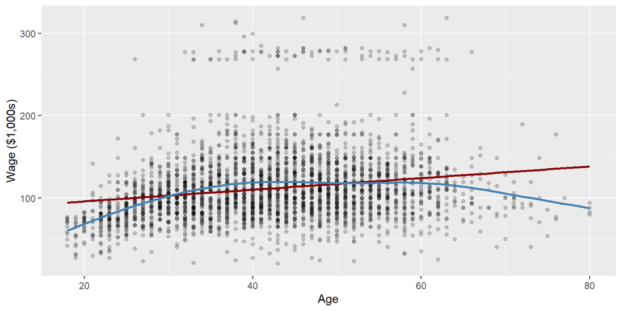

```r
ggplot(Wage, aes(age, wage)) +
  geom_point(alpha = 0.2) +
  geom_smooth(method = "lm", se = FALSE, color = "darkred") +
  geom_smooth(method = "gam", se = FALSE, color = "steelblue") +
  labs(x = "Age", y = "Wage ($1,000s)")
```

*Where does the straight line fit badly?* At both ends. The flexible (blue) line climbs steeply from the late teens to about 40, stays roughly flat through the 40s and 50s, then **falls after about 60**. The straight line can only go up at one constant rate, so it sits too high for the youngest workers, too low through the middle of the career, and too high again for the oldest.

The group means by age tell the same story:

```r
Wage %>%
  mutate(age_group = cut(age, c(17, 25, 35, 45, 55, 65, 80))) %>%
  group_by(age_group) %>%
  summarise(n = n(), mean_wage = round(mean(wage), 1))
```

```
## # A tibble: 6 × 3
##   age_group     n mean_wage
##   <fct>     <int>     <dbl>
## 1 (17,25]     231      76.3
## 2 (25,35]     670     104.
## 3 (35,45]     894     119.
## 4 (45,55]     795     118.
## 5 (55,65]     346     119
## 6 (65,80]      64     103.
```

Wages rise by about $43,000 between the youngest group and the 35–45 group, barely move for the next 20 years, then drop for workers over 65.

### Task 2.2: Give the model something that can bend

```r
Wage <- Wage %>% mutate(age2 = age^2)

summary(lm(wage ~ age + age2, data = Wage))$r.squared
```

```
## [1] 0.08208515
```

*How much did R-squared improve?* From **0.038 to 0.082** — more than double.

*Where did the improvement come from?* Not from new data: `age2` is built entirely from `age`. It came from **shape**. With `age` and `age2` together, the model can draw a curve that rises and then turns down, which matches the data far better than a straight line.

## Part 3: Turn a Category Into a Number

### Task 3.1: Build an indicator

```r
levels(Wage$education)
```

```
## [1] "1. < HS Grad"       "2. HS Grad"         "3. Some College"
## [4] "4. College Grad"    "5. Advanced Degree"
```

```r
Wage <- Wage %>%
  mutate(college = if_else(education %in% c("4. College Grad", "5. Advanced Degree"),
                           1, 0))
```

`%in%` checks whether each worker’s `education` is **one of** the listed levels. The level names must match exactly, number prefix included — `"College Grad"` without the `"4. "` matches nothing, and every worker would get a 0.

### Task 3.2: Does it separate the data?

```r
Wage %>%
  group_by(college) %>%
  summarise(n = n(), mean_wage = round(mean(wage), 1))
```

```
## # A tibble: 2 × 3
##   college     n mean_wage
##     <dbl> <int>     <dbl>
## 1       0  1889      98.2
## 2       1  1111     135.
```

*How big is the gap?* College graduates average **$134,600**, everyone else **$98,200** — a gap of about **$36,000**, or roughly 37% more. (1,111 of the 3,000 workers are in the college group.)

### Task 3.3: Add it to the model

```r
summary(lm(wage ~ age + age2 + college, data = Wage))$r.squared
```

```
## [1] 0.2333926
```

R-squared jumps from **0.082 to 0.233**.

*Which bought you more?* **Knowing whether someone went to college, by a wide margin.** Squaring age added about 0.04; the college indicator added about 0.15 — more than three times as much. The transformation fixed the *shape* of a weak predictor; the indicator brought in a much stronger *source* of information.

## Part 4: Combine Features

### Task 4.1: A reasonable hypothesis

```r
slope_no_college <- coef(lm(wage ~ age, data = filter(Wage, college == 0)))[["age"]]
slope_college    <- coef(lm(wage ~ age, data = filter(Wage, college == 1)))[["age"]]

c(no_college = slope_no_college, college = slope_college)
```

```
## no_college    college
##  0.5911078  0.5823663
```

The two slopes are almost identical: about **0.59** (thousand dollars per year of age) for both groups. The data does not support the story that graduates’ wages grow faster with age.

### Task 4.2: Test the interaction

```r
Wage <- Wage %>% mutate(age_x_college = age * college)

summary(lm(wage ~ age + college, data = Wage))$r.squared
```

```
## [1] 0.2032085
```

```r
summary(lm(wage ~ age + college + age_x_college, data = Wage))$r.squared
```

```
## [1] 0.2032097
```

*What happened to R-squared?* **Nothing.** It moves from 0.2032085 to 0.2032097 — a change in the sixth decimal place.

(Both numbers are below Task 3.3’s 0.233 because these models leave out `age2`. That’s fine: the comparison that matters is with and without the interaction, holding everything else the same.)

*Does that make sense?* Yes. An interaction lets the two groups have **different slopes**. Task 4.1 showed the slopes are already the same, so there is no difference for the interaction to capture. College graduates earn more at every age (the `college` indicator handles that by shifting the line up), but their wages don’t grow any faster.

### Task 4.3: The important part

*Keep it, drop it, or keep looking?* **Drop it — and write down that you tested it.** The economic story was reasonable, but the data didn’t back it up. Keeping a feature that adds nothing makes the model harder to explain and gives it one more number to fit by chance.

“Keep looking” is also a fine answer, as long as it means testing a *different* idea with its own reason behind it, not reshaping this one until something clears the bar.

*What if you’d added it without checking?* You would be reporting a story — “experience pays more for graduates” — that the data doesn’t support. The model would still run, the coefficient would still print, and nothing would warn you. The interaction coefficient here is **−0.009**: tiny, and not distinguishable from zero. Checking is what tells you that.

## Part 5: Build Your Own (bonus)

Any feature works if you **state a reason first** and then test it honestly. Here is one worked example.

**Reason:** jobs that come with health insurance tend to be full-time, stable positions, which usually pay more.

```r
Wage <- Wage %>% mutate(has_ins = if_else(health_ins == "1. Yes", 1, 0))

Wage %>% group_by(has_ins) %>% summarise(n = n(), mean_wage = round(mean(wage), 1))
```

```
## # A tibble: 2 × 3
##   has_ins     n mean_wage
##     <dbl> <int>     <dbl>
## 1       0   917      92.3
## 2       1  2083     120.
```

```r
summary(lm(wage ~ age + age2 + college + has_ins, data = Wage))$r.squared
```

```
## [1] 0.2747582
```

Workers with insurance average about $28,000 more, and R-squared rises from **0.233 to 0.275**. The prediction was right.

Be careful with the interpretation, though. Insurance probably doesn’t *raise* wages — it’s a marker of the kind of job that pays well. That’s fine for prediction; it isn’t a cause.

For comparison, here is what each untouched column adds to the Task 3.3 model (baseline 0.233), using one indicator each:

| Feature | Definition | R-squared |
| --- | --- | --- |
| `has_ins` | has health insurance | 0.275 |
| `married` | `maritl` is “2. Married” | 0.253 |
| `info` | `jobclass` is “2. Information” | 0.240 |
| `year` | survey year, as a number | 0.237 |

Every one of these helps a little. That is exactly why the reason has to come first: with enough columns, *something* will always nudge R-squared up.

## Wrap-up & Discussion

**1. Rank the features by how much they improved R-squared.**

`college` (+0.15) ≫ `age2` (+0.04) ≫ `age_x_college` (≈ 0). The ranking doesn’t line up with how interesting each one sounds. The interaction had the richest economic story and added nothing; the plainest feature, a 0/1 for college, did the most work.

**2. Why report the negative result from Task 4?**

Because a reader can’t tell the difference between “we didn’t test it” and “we tested it and it failed” unless you say so. Reporting it keeps someone else from wasting time on the same idea, and it’s honest about how many things you tried — if you tested ten features and only report the two that worked, those two look more convincing than they should.

**3. Building features vs. collecting more data?**

Every feature today was a new way of *looking at* information already in the dataset: squaring `age` reshaped it; `college` summarized `education`. That can only help the model use what’s there. Collecting data — occupation, hours worked, region — adds information the model never had. Feature engineering can’t create signal that isn’t in the columns.

**4. What if you kept inventing features until R-squared hit 0.9?**

With enough squares, cubes and products, the model starts fitting the random noise in *these* 3,000 workers rather than the pattern that holds for workers in general. It would look excellent here and predict new workers badly. This is **overfitting**, and it’s why every feature needs a reason, not just a better number.